# How Many Images?

Alex Barth

## Goals of this analysis

Our team is building planktoscope to deploy to existing volunteer plankton monitoring groups.  
Ideally, we can provide an exact protocol for all volunteers to follow. Volunteers should collect a specified volume and then collect a specified number of images. Clearly, sampling a larger volume will allow for better data. There are two ways to increase volume sampled:  
1. Take more images  
2. Concentrate the sample  
However, both these methods have issues. First, volunteers are limited in their time so I want to minimize how much time they have to spend collecting images. Additionally, more images will requir more time for the segmenter, which can be quite slow. Second, there is a practical limitation to how concentrated a sample is. If there are too many objects in the frame, the segmenter won’t function well. Additionally fluidic paths can clog.  
To figure out how many samples, I collected samples from Oyster Landing, North Inlet, SC. I also investigated if the fluidic pathway (syringe or beaker) had a large impact. I collected samples of either 10 or 15 gallons concentrated into a 250mL container. I filtered these samples with 200 micron mesh. I then ran them through two planktoscopes. One sampled from a beaker while the other used a syringe (classic set-up). I took 500 images. In thsi analysis, I am subsampling from images to get an idea of variability if I were to have taken less images.  
Ideally, this would be ran multiple times. However this will at least provide a guideline idea. This process would also need to be done repeatedly in different systems.  
There are two main goals:  
- Get a stable density estimate for key taxa  
- Adequately sample community diversity

### How stable are density estimates?

First a look at diatoms: These are the most common taxa in this sample. Primarily a mix of several chaetoceros chains.

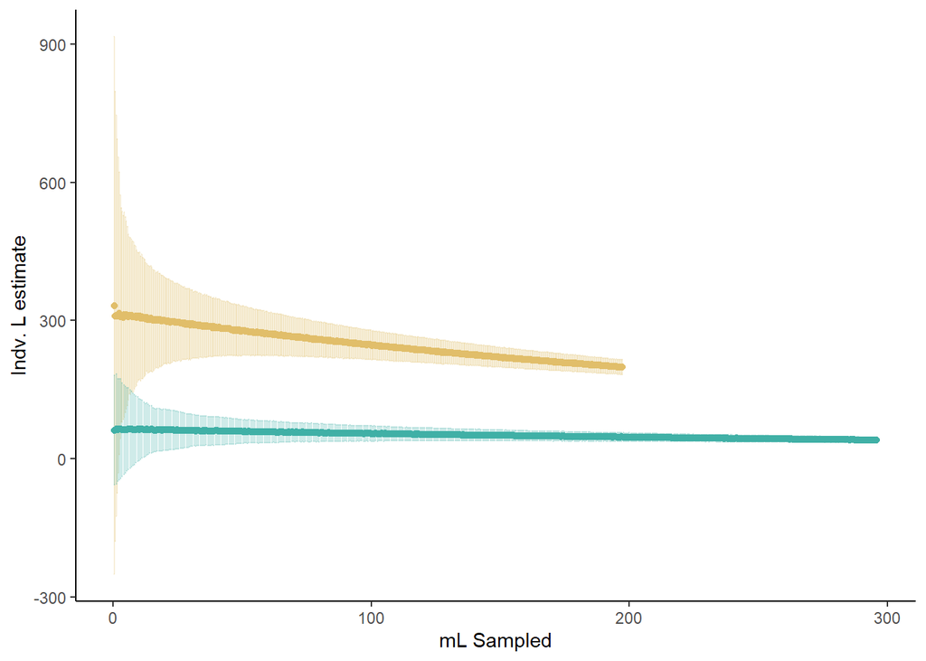

Diatom denisty estimate. Yellow is the 10gal concentrated and Blue-Green is 15gal concentrated. These data were ran using the syringe method

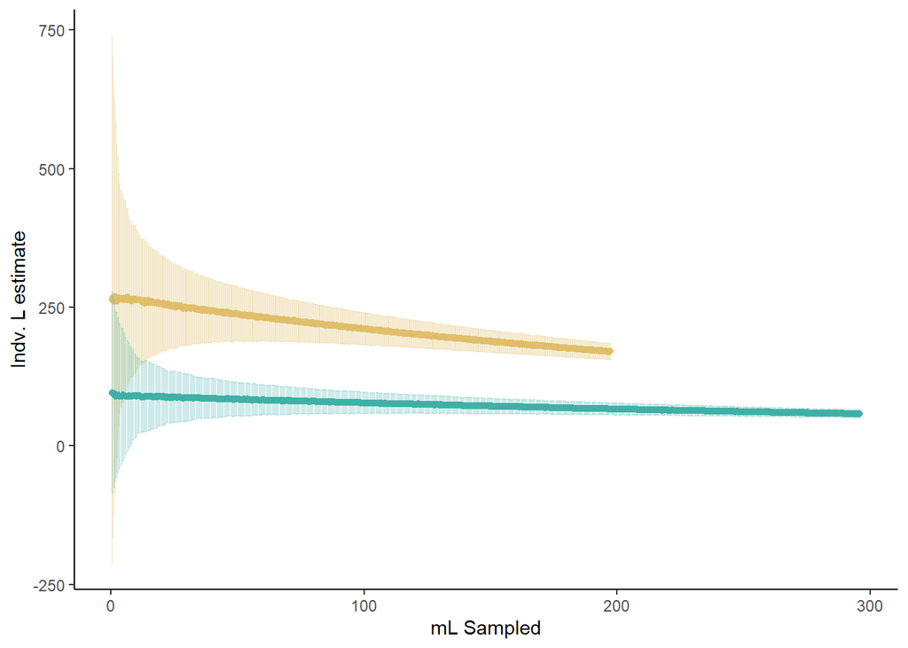

Diatom denisty estimate. Yellow is the 10gal concentrated and Blue-Green is 15gal concentrated. These data were ran using the beaker method

Next a look at the mesozooplankton. These are primarily different copepods and copepidites.

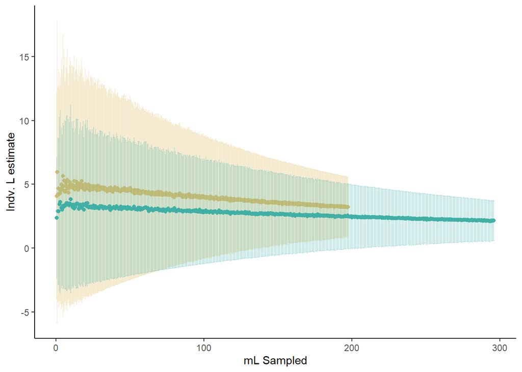

Mesozooplankton denisty estimate. Yellow is the 10gal concentrated and Blue-Green is 15gal concentrated. These data were ran using the syringe method

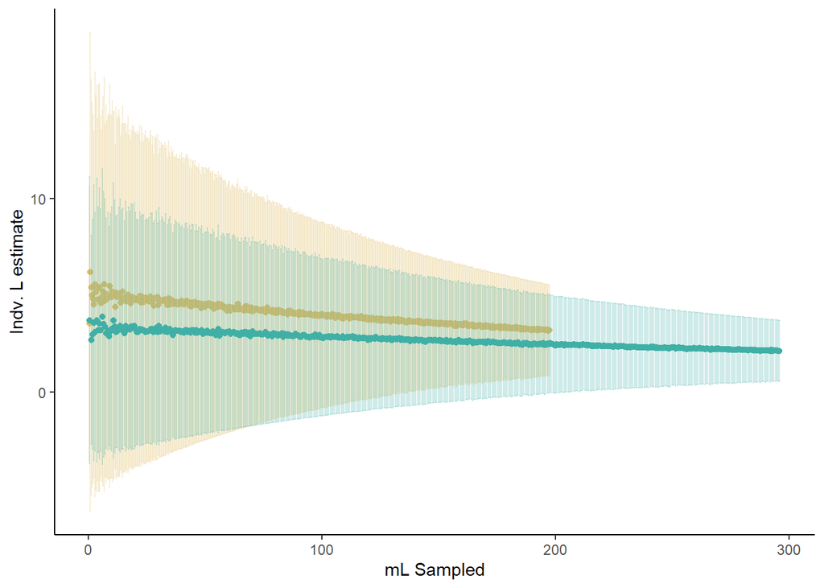

Mesozooplankton denisty estimate. Yellow is the 10gal concentrated and Blue-Green is 15gal concentrated. These data were ran using the beaker method

Finally a look at ciliates, heterotophic protists, and dinoflagellates.

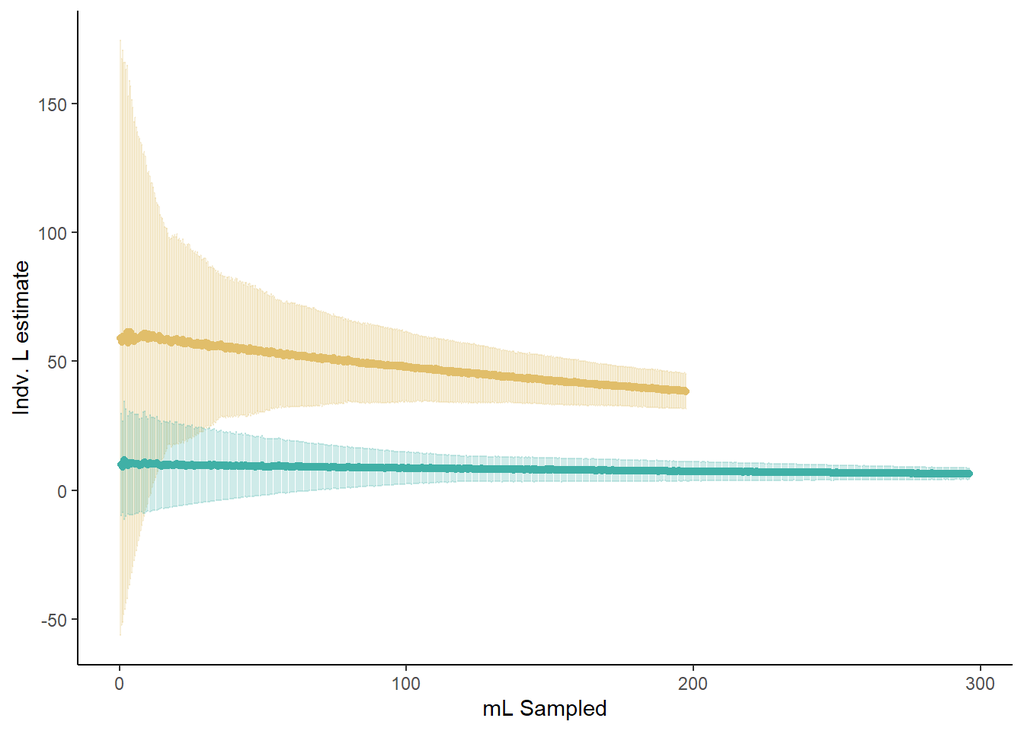

Mixed cateogry denisty estimate. Yellow is the 10gal concentrated and Blue-Green is 15gal concentrated. These data were ran using the syringe method

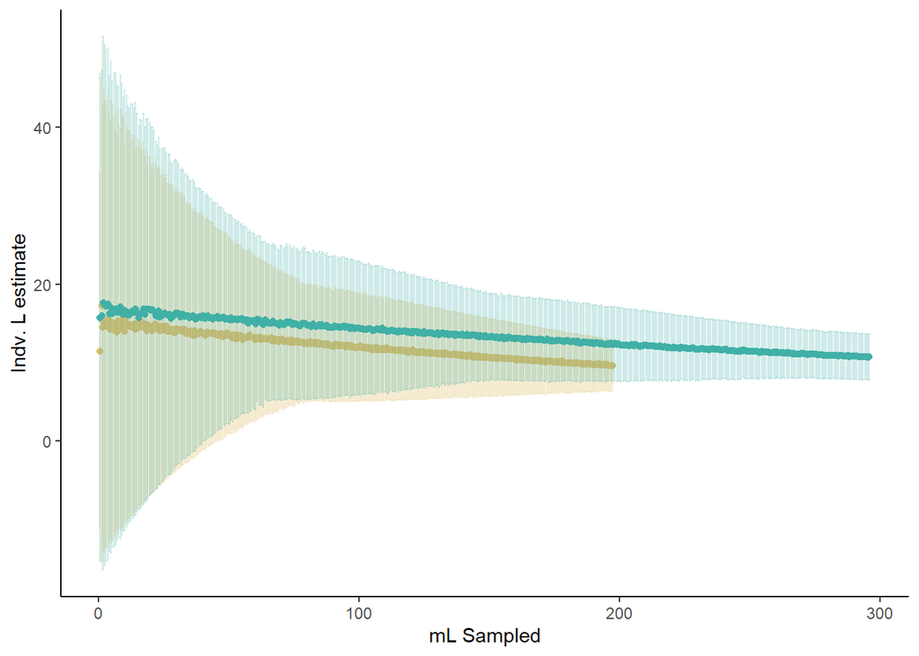

Mixed cateogry denisty estimate. Yellow is the 10gal concentrated and Blue-Green is 15gal concentrated. These data were ran using the beaker method

# Now what does this rarefication curve look like?

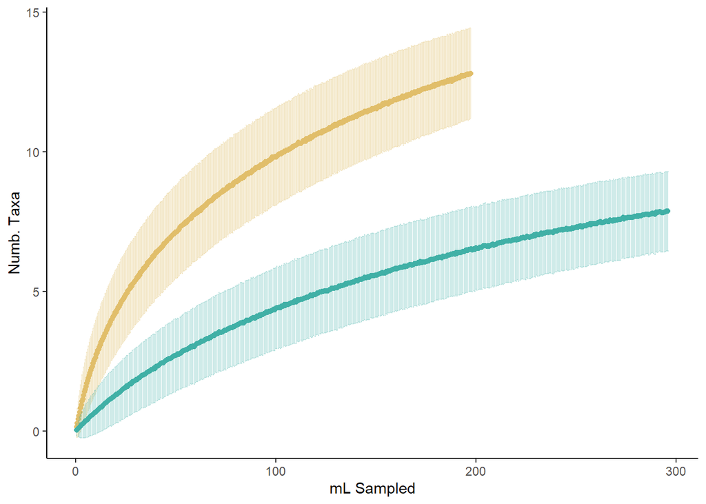

Richness curve for the syringe sampling method

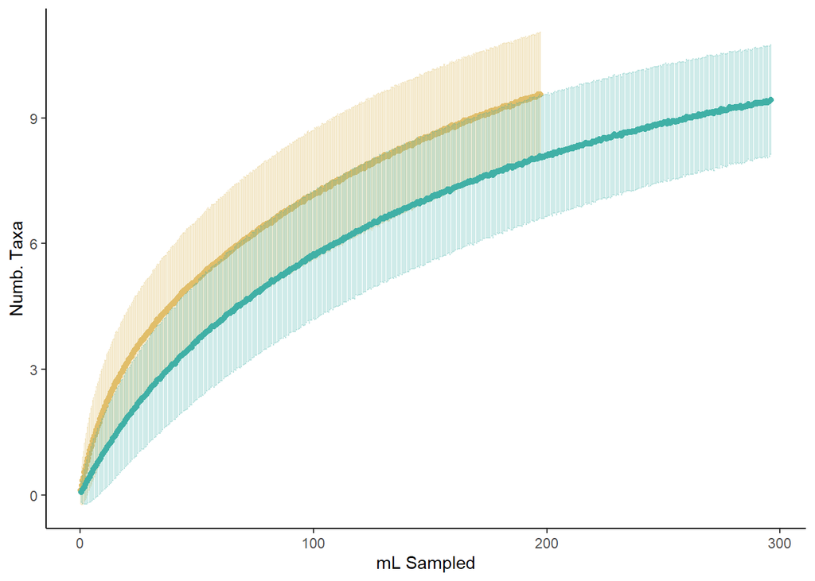

Richness curve for the beaker sampling method